### Algorithmic Machine Learning Challenge

# Plankton Image Classification

Notebook realized by DESVIGNES Mailys and JAY Mathilde - May, the 3rd 2019

## Introduction

To solve this challenge, which is find the plankton label2 associated to a certain image, we chose to use convolutionnal neural network because it was the model we knew the less. To do so, we used the keras library.

In the notebook, you will find the following parts:

- Data Exploration
- Distribution of the different labels that the images are assigned to
- Distribution of the different image dimensions
- Data Pre-processing
- Image size study
- Image resizing
- Data splitting
- Data generation
- Model selection
- CNN
- Dataset selection
- Optimization as regards to hyper parameters
- Test of different architectures
- Model choice

#### Module import

```python
# !pip3 install --user keras
```

```python
%matplotlib inline
import os
import sys
import re
import random
import matplotlib
import implicit

import matplotlib.pyplot as plt
import pandas as pd
import numpy as np
import seaborn as sns

from sklearn.model_selection import train_test_split
from sklearn.ensemble import IsolationForest
from sklearn.metrics import accuracy_score,precision_score,confusion_matrix
from sklearn.model_selection import GridSearchCV
from sklearn.preprocessing import LabelEncoder, normalize
from sklearn.metrics import f1_score

import tensorflow as tf

#preprocessing
from keras.preprocessing.image import ImageDataGenerator

#dl libraraies
from keras import backend as K
from keras.models import Sequential
from keras.layers import Dense
from keras.optimizers import Adam,SGD
from keras.utils import to_categorical
from keras.callbacks import ReduceLROnPlateau

# specifically for cnn
from keras.layers import Dropout, Flatten,Activation
from keras.layers import Conv2D, MaxPooling2D, BatchNormalization, AveragePooling2D
from keras import optimizers

from tqdm import tqdm
from time import time
```

#### Images loading

```python
import zipfile
from io import BytesIO
from PIL import Image

def extract_zip_to_memory(input_zip):
    '''
    This function extracts the images stored inside the given zip file.
    It stores the result in a python dictionary.

    input_zip (string): path to the zip file

    returns (dict): {filename (string): image_file (bytes)}
    '''
    input_zip=zipfile.ZipFile(input_zip)
    return {name: BytesIO(input_zip.read(name)) for name in input_zip.namelist() if name.endswith('.jpg')}


#img_files = extract_zip_to_memory("/mnt/datasets/plankton/flowcam/imgs.zip")
```

## Data Exploration

### Distribution of the different labels that the images are assigned to

```python
metaDF = pd.read_csv('/mnt/datasets/plankton/flowcam/meta.csv')
metaDF[0:2]
```

|  | objid | projid | id | status | latitude | longitude | objdate | objtime | depth_min | depth_max | unique_name | lineage | level1 | level2 |
| --- | --- | --- | --- | --- | --- | --- | --- | --- | --- | --- | --- | --- | --- | --- |
| 0 | 32756761.0 | 133 | 84963 | V | 43.683333 | 7.3 | 2013-09-19 | 00:09:00 | 0 | 75 | detritus | /#/not-living/detritus | detritus | detritus |
| 1 | 32759364.0 | 133 | 84963 | V | 43.683333 | 7.3 | 2013-09-19 | 00:09:00 | 0 | 75 | detritus | /#/not-living/detritus | detritus | detritus |

Let's see on which classification level we should work.

```python
print ("Nb pictures having a classification of level2 different from the level 1 :", metaDF['objid'][metaDF['level2'] != metaDF['level1']].count())
print("Total n. of level1 label: ", metaDF['level1'].nunique())
print("Total n. of level2 label: ", metaDF['level2'].nunique())
```

```
Nb pictures having a classification of level2 different from the level 1 : 18895
Total n. of level1 label:  56
Total n. of level2 label:  39
```

Indeed we should work on level2 classification because there are only 18 895 different images which don't have the same level1 label as the level2 one. And with the level1 classification, there are more than 50 different label which may add useless complexity to our model.

```python
uniquePhotos = metaDF['objid'].nunique()
metaDF.dropna(subset=['level2'], how='all', inplace = True)
uniquePhotos2 = metaDF['objid'].nunique()

print("Total n. of photos: ", uniquePhotos2)
print("Total n. of photos without any level2 data:", uniquePhotos - uniquePhotos2)
```

```
Total n. of photos:  242607
Total n. of photos without any level2 data: 1003
```

Our dataset is composed of 242 607 samples, which is a good number to make a model and train it. However we'll have to see if this will be enough to distinguish all the different types of plankton. Indeed small amount data might only be available for a particular type of plankton. First, let's have a look at the repartition of the images and how often is a plankton detected.

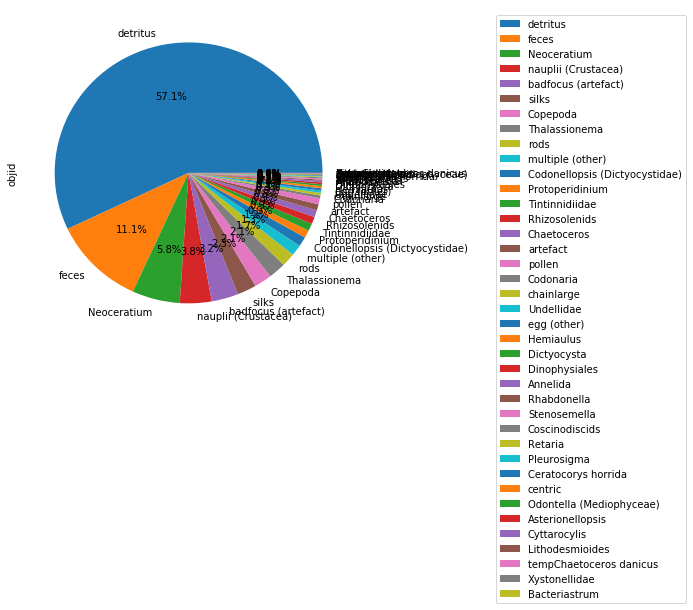

```python
metaDF_sort= metaDF[['objid','level2']].groupby('level2').count()
metaDF_sort_best=metaDF_sort.sort_values(by='objid', ascending=False)

plot = metaDF_sort_best.plot.pie(y='objid',autopct='%1.1f%%', figsize=(6, 6))
plot.get_legend().set_bbox_to_anchor((2, 1))
plt.show()
```

```
objid    20
dtype: int64
```

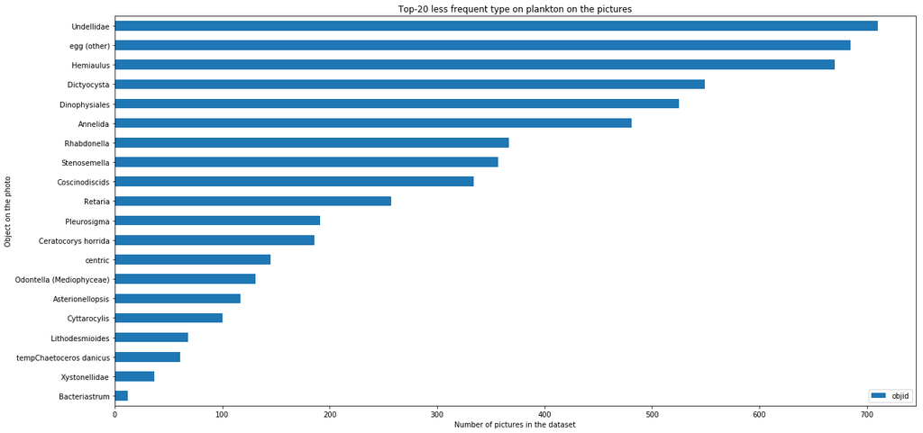

```python
metaDF_sort= metaDF[['objid','level2']].groupby('level2').count()
metaDF_sort_best=metaDF_sort.sort_values(by='objid', ascending=True)[:20]
print(metaDF_sort_best.nunique())
fig, ax = plt.subplots(figsize=(20, 10))
metaDF_sort_best.plot(kind = 'barh',ax=ax)

ax.set_xlabel('Number of pictures in the dataset')
ax.set_ylabel('Object on the photo')
ax.set_title('Top-20 less frequent type on plankton on the pictures')

plt.show()
```

This chart confirms that for than half of the plankton types, we have less than 1000 images which is very poor to feed a neural network. This will be difficult for our model to distinguish the different type of plankton. For instance Bacteriastrum has only 12 pictures. To try to deal with this, we will generate new data by rotating and translating the images.

### Distribution of the different image dimensions

Let's vizualise first!

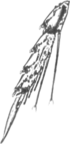

```python
img_files = extract_zip_to_memory("/mnt/datasets/plankton/flowcam/imgs.zip")
Image.open(img_files['imgs/32734640.jpg'])
```

The images are to be in black and white, so we won't need to deal with colors. We can notice that images are very diversified with many different sizes. We'll have to deal with these oulier images, in order to scale correctly all our images with an appropriate size without loosing a lot of information (especially for the 2-3 types of plankton not well represented).

The goal is both to align images size and to minimize the weight of the images we are going to feed our model with, to optimize the duration of the computation and the results.

Let's analyse the different sizes of the images in order to know at which size we should sacle our images to loose minimum data.

```python
size_im=[]
for i in tqdm(img_files):
    img=Image.open(img_files[i])
    size_im.append(img.size)
size_images=np.array(size_im)

del img_files #don't need that for now
```

```python
print("Mean of images width: %0.2f (+/- %0.2f)" % (size_images[:,0].mean(), size_images[:,0].std()))
print("Mean of images height: %0.2f (+/- %0.2f)" % (size_images[:,1].mean(), size_images[:,1].std()))
print("Shape of the 1/100 smallest image: %0.2f, %0.2f" % (np.sort(size_images, axis=0)[int(np.size(size_images)*1/100)][0], np.sort(size_images, axis=0)[int(np.size(size_images)*1/100)][1]))
```

```
Mean of images width: 86.63 (+/- 62.15)
Mean of images height: 109.34 (+/- 71.93)
Shape of the 1/100 smallest image: 20.00, 35.00
```

As the standard deviation shows, the size of the images is very diversified. Let's vizualize this distribution.

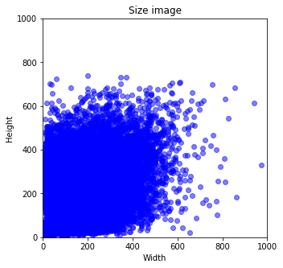

```python
fig = plt.figure(1, figsize=(5, 5))
cmap = plt.cm.get_cmap("autumn")
plt.scatter(size_images[:,0],size_images[:,1], c ="b",marker = "o", alpha=0.5,
            label="Size images")
#plt.scatter(size_images[:,0],size_images[:,1], c = pred_outlier*2, cmap=cmap,marker = "o", alpha=0.5,label="Size images")
plt.xlabel("Width")
plt.ylabel("Height")
axes = plt.gca()
axes.set_xlim(0, 1000)
axes.set_ylim(0, 1000)
plt.title("Size image")
plt.show()
```

We can see that some images have a size inferior to 10x10 pixels whereas some have a size superior to 600x600 pixels. We'll have to deal with the image sizes, to avoid long computation time. To have an idea of the size to rescale our image, let's have amore precise idea of the distribution.

```
number of 'outliers' :  2437
```

```
number of 'outliers' :  6091
```

```
number of 'outliers' :  12181
```

```
number of 'outliers' :  24361
```

```
number of 'outliers' :  48728
```

```
number of 'outliers' :  97448
```

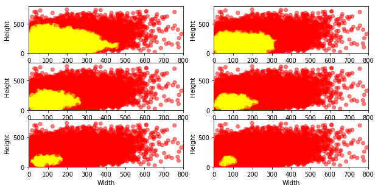

```python
contamination=[0.01,0.025,0.05,0.1,0.2,0.4]
plt.figure(figsize=(10,10))
#plt.gcf().subplots_adjust(left = 0.1, bottom = 0.1,right = 0.5, top = 0.5, wspace = 0.4, hspace =0.5)

for i in tqdm(range(len(contamination))):
    plt.subplot(len(contamination),2,i+1)

    ### Isolation Forest algorithm ###
    clf = IsolationForest(contamination=contamination[i])
    clf.fit(size_images)
    pred_outlier = clf.predict(size_images)
    print("number of 'outliers' : ",len(pred_outlier[pred_outlier==-1]))

    ### Plots ###
    plt.scatter(size_images[:,0],size_images[:,1], c = pred_outlier*2, cmap=cmap,marker = "o", alpha=0.5,
            label="Size images")
    plt.xlabel("Width")
    plt.ylabel("Height")
    axes = plt.gca()
    axes.set_xlim(0, 800)
    axes.set_ylim(0, 800)

plt.show()
```

In red are the "outliers" detected by the isolation forest algorithm. We can see that the majority of the images (98%) have a size inferior to 400x400 pixels and 60% of them between 50 and 100 pixels.

## Data pre-processing

To use a CNN model, we have to be sure that our image have the same ratio.

Following the idea that the best image size is the size of the smallest image we choose:

```python
IMG_SIZE = 50
```

### Image resizing

```python
def in_array(DF,size):
    '''
    Put the whole dataset into the right dimension and a np.array.
    arg:
        DF : dataframe with the object names associated with the level2 label.
        size: size of the wanted image side
    return:
        X: array of image array
    '''
    names = DF['objid'].astype('int').astype('str')

    #load the images
    img_files = extract_zip_to_memory("/mnt/datasets/plankton/flowcam/imgs.zip")

    X = []

    for i in tqdm(names):
        img = Image.open(img_files['imgs/'+i+'.jpg'])

        img = img.resize((size, size), Image.ANTIALIAS)
        X.append(np.array(img))

    del img_files #don't need that anymore
    X = np.array(X)

    #normalization: will be done later
    #X = (X-np.mean(X))/np.std(X)

    return X
```

```python
def labeling2(DF):
    '''
    Put all the label into integers (between 1 and 39)
    '''
    #encoding the labels
    le=LabelEncoder()
    labels= DF['level2'].values
    Y = le.fit_transform(labels)
    #Y=to_categorical(Y,39)

    return Y
```

```python
X = in_array(metaDF,IMG_SIZE) #2:24min to compute the loop
X.shape
```

```
(242607, 50, 50)
```

```python
Y = labeling2(metaDF)
Y.shape
```

```
(242607,)
```

### Data splitting

```python
#Let's first get the validation set
x_train, x_val, y_train, y_val = train_test_split(X,Y, test_size=0.1, random_state=42)
```

```python
#Let's not use the whole data set for now, and make sure we don't always use the same images
def get_samples(X,Y,size):
    '''
    Return a number of random images with their label
    '''
    Z = np.random.permutation(list(zip(X,Y)))[:size]
    A,B = zip(*Z)
    A,B = np.array(A),np.array(B)
    return A,B
```

```python
training_data_set_size = 50000 #for example
X_small, Y_small = get_samples(x_train,y_train,training_data_set_size)
```

```python
X_small.shape
```

```
(50000, 50, 50)
```

```python
def get_train_test_sets(X,Y,IMG_SIZE):
    '''
    split the train dataset and reshape the train and test dataset
    '''
    x_train, x_test, y_train, y_test = train_test_split(X,Y, test_size=0.25, random_state=42)
    x_train=x_train.reshape(-1,IMG_SIZE,IMG_SIZE,1)
    y_train=y_train.reshape(-1,1)
    x_test=x_test.reshape(-1,IMG_SIZE,IMG_SIZE,1)
    y_test=y_test.reshape(-1,1)
    return x_train, x_test, y_train, y_test
```

```python
x_train, x_test, y_train, y_test = get_train_test_sets(X_small,Y_small,IMG_SIZE)
```

```python
x_train.shape
```

```
(37500, 50, 50, 1)
```

### Data generation

The obvious lack of sample for some plankton type led us to consider generate data, using a keras class. There are two ways to do so. First, The ImageDataGenerator can be used to generate batch of data directly when the model is running but this implies that we don't have the choice of the image from which is generated. And we would like to only generated data from images of under-represented plankton. Also, as you will soon see, we didn't good results with this approach. That's why we developped our own function to transform our images (flip horizontal and vertical, and 45 rotation), still using the ImageDataGenerator class.

```python
datagen = ImageDataGenerator(
    featurewise_center=True,
    featurewise_std_normalization=True,
    rotation_range=20,
    width_shift_range=0.2,
    height_shift_range=0.2,
    horizontal_flip=True)
```

```python
def less_represented_plankton(DF,size):
    metaDF_sort= DF[['objid','level2']].groupby('level2').count()
    metaDF_sort_best=metaDF_sort.sort_values(by='objid', ascending=True)[:size]
    metaDF_sort_best = list(metaDF_sort_best.index)

    #labelize
    labels = le.transform(metaDF_sort_best)

    return labels
```

```python
def handmade_generation(X,Y,size,labels):
    '''
    labels: des chiffres et pas des lettres !
    '''
    #3 different tranformations
    dico = {}
    dico['flip_vertical']=True
    dic = {}
    dic['flip_horizontal']=True
    di = {}
    di['theta']=0.45

    new_X= []
    new_Y= []

    for n in range(len(X)):
        if len(new_X)<size: #To control the number of images to generate
            if Y[n][0] in labels: #To control which image to select
                new_X.append(datagen.apply_transform(X[n],dico))
                new_X.append(datagen.apply_transform(X[n],dic))
                new_X.append(datagen.apply_transform(X[n],di))
                new_Y.append(Y[n])
                new_Y.append(Y[n])
                new_Y.append(Y[n])

    new_X = np.array(new_X)
    new_Y = np.array(new_Y)
    return new_X,new_Y
```

```python
#on the whole dataset
x_train, x_test, y_train, y_test = get_train_test_sets(X,Y,IMG_SIZE)

datagen.fit(x_train)

wanted_labels = less_represented_plankton(metaDF,20)

new_X,new_Y = handmade_generation(x_train,y_train,50000,wanted_labels)

x_bigger,y_bigger= np.concatenate((x_train, new_X), axis=0),np.concatenate((y_train, new_Y), axis=0)
```

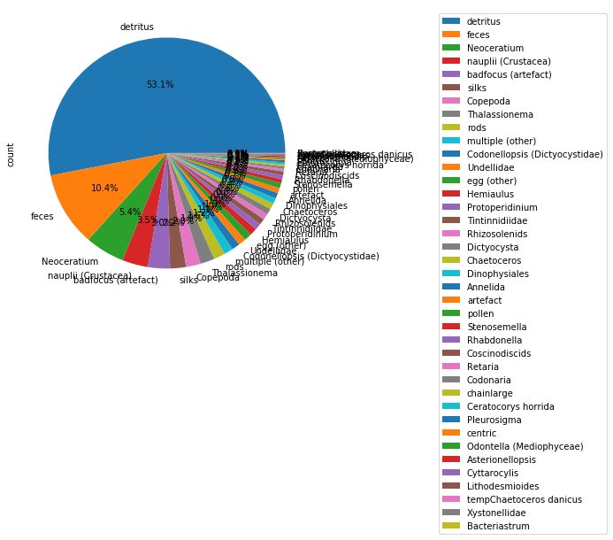

```python
#Let's vizualise!

tab = np.unique(y_bigger, return_counts=True)
d = { 'count': tab[1]}
df = pd.DataFrame(d,index=le.inverse_transform(tab[0])).sort_values(by='count',ascending=False)

plot = df.plot.pie(y='count',autopct='%1.1f%%', figsize=(6, 6))
plot.get_legend().set_bbox_to_anchor((2, 1))
plt.show()
```

## Model Selection

As part of the model selection, we:

- Chose a first model
- Tried the different pre-processed datasets (with or without generated data and with or without normalization), we started to test our model with those different dataset and selected one
- Optimized the hyperparameters
- Tried differents architectures

### Multi convolutionnal layer CNN

In our research, we found several ways to implement a CNN. The first we implemented was inspired from the following tutorial: https://towardsdatascience.com/image-classification-python-keras-tutorial-kaggle-challenge-45a6332a58b8. We chose this one because it was one of the easiest to understand and yet complexe enough. Also, its problem is quite the same as ours: classification of black and white images. The CNN is composed of several keras conv2D layers with different output size, maximum pooling and batch normalization which are three caracteristics proven to be most efficient in image classification. The model ends with a drop_out layer to reduce overfitting and two dense layer to cast the results into our labels.

```python
model = Sequential()
model.add(Conv2D(32, kernel_size = (3, 3), activation='relu', input_shape=(IMG_SIZE, IMG_SIZE, 1)))
model.add(MaxPooling2D(pool_size=(2,2)))
model.add(BatchNormalization())

model.add(Conv2D(64, kernel_size=(3,3), activation='relu'))
model.add(MaxPooling2D(pool_size=(2,2)))
model.add(BatchNormalization())

model.add(Conv2D(64, kernel_size=(3,3), activation='relu'))
model.add(MaxPooling2D(pool_size=(2,2)))
model.add(BatchNormalization())

model.add(Conv2D(32, kernel_size=(3,3), activation='relu'))
model.add(MaxPooling2D(pool_size=(2,2)))
model.add(BatchNormalization())

model.add(Dropout(0.2))

model.add(Flatten())
model.add(Dense(128, activation='relu'))
model.add(Dense(39, activation = 'softmax')) #number of level2 label

#compilation
model.compile(optimizer='adam',
          loss='sparse_categorical_crossentropy',
          metrics=['accuracy'])
```

#### Dataset selection

**50 000 images - No normalization - No image generation**

To begin with, we trained our model with our 'raw' data, to have a base to compare the other data with.

```python
#training_data_set_size = 200000, no normalization, without data generation
model.fit(x_train,y_train,validation_data=(x_test,y_test),batch_size = 50, epochs = 3, verbose = 1)
```

```
Train on 37500 samples, validate on 12500 samples
```

```
<keras.callbacks.History at 0x7f2fa9ae4b00>
```

```python
y_pred=model.predict(x_test, verbose = 0) #proba
```

```python
predictions = np.argmax(y_pred, axis=-1)
print('Macro f1_score:')
print(f1_score(y_test, predictions, average='macro'))
print('f1_score for each label:')
print(f1_score(y_test, predictions, average=None))
```

```
Macro f1_score:
0.18283804182593824
f1_score for each label:
[0.         0.         0.         0.25868726 0.         0.50179211
 0.33479404 0.         0.         0.         0.         0.
 0.         0.61514442 0.         0.         0.25757576 0.
 0.         0.21518987 0.         0.65561694 0.04651163 0.26666667
 0.         0.50285714 0.86018642 0.         0.         0.79050771
 0.         0.44942023 0.03191489 0.33860574 0.         0.37062937
 0.45174538 0.        ]
```

This is definitly not as good as what we got on the previous challenges, which is not alarming since:

- We didn't optimize the model at all
- We have small amount of data for some categories - and the f1 score is an average of the accuracy on each label

To better understand our results, we constructed a confusion matrix showing which label was predicted as which label.

```python
from sklearn.utils.multiclass import unique_labels

def plot_confusion_matrix2(y_true, y_pred, classes, size, text=True,
                          normalize=False,
                          title=None,
                          cmap=plt.cm.YlOrRd):

    y_true=y_true.reshape(-1)
    if not title:
        if normalize:
            title = 'Normalized confusion matrix'
        else:
            title = 'Confusion matrix, without normalization'

    # Compute confusion matrix
    cm = confusion_matrix(y_true, y_pred)
    # Only use the labels that appear in the data
    classes = classes[unique_labels(y_true, y_pred)]
    if normalize:
        cm = cm.astype('float') / cm.sum(axis=1)[:, np.newaxis]
        print("Normalized confusion matrix")
    else:
        print('Confusion matrix, without normalization')

    print(cm)

    fig, ax = plt.subplots(figsize=(size,size))
    im = ax.imshow(cm, interpolation='nearest', cmap=cmap)
    ax.figure.colorbar(im, ax=ax,)
    # We want to show all ticks...
    ax.set(xticks=np.arange(cm.shape[1]),
           yticks=np.arange(cm.shape[0]),
           # ... and label them with the respective list entries
           xticklabels=classes, yticklabels=classes,
           title=title,
           ylabel='True label',
           xlabel='Predicted label')

    # Rotate the tick labels and set their alignment.
    plt.setp(ax.get_xticklabels(), rotation=90, ha="right",
             rotation_mode="anchor")

    # Loop over data dimensions and create text annotations.
    if text==True:
        fmt = '.2f' if normalize else 'd'
        thresh = cm.max() / 2.
        for i in range(cm.shape[0]):
            for j in range(cm.shape[1]):
                if cm[i,j]>0:
                    ax.text(j, i, format(cm[i, j], fmt),ha="center", va="center",color="white" if cm[i, j] > thresh else "black")
        fig.tight_layout()
    return ax
```

[figure not shown]

```python
plot_confusion_matrix2(y_test, predictions, 20)
```

This confusion matrix allows us to see how the labels have been predicted for each class.

First of all, we can notice that our model is not good, indeed the diagonal coefficients of this matrix are very bad, which means that for each class, only few images have been correctly classified.

Secondly, we see that some labels lead to confusion. Some columns of the matrix are totally coloured which means that the label of this column has been predicted at least once for a different label. For instance, regarding the 'detritus' column, we can see many images have been classified as detritus. This is due to the important proportion of detritus images (;ore than 50% of the dataset). We can also observe it for the Neoceratium which is the most represented plankton of the dataset. To solve this issue, we will increase the proportion of the less frequent plankton images.

**20 000 - No normalization - Yes image generation**

Here we are not using the images we generated manualy.

```python
epochs = 3

# With generated data, 20 000 images, no normalization
model.fit_generator(datagen.flow(x_train, y_train, batch_size=50),
                    steps_per_epoch=len(x_train) / 50, epochs=epochs)
```

```
<keras.callbacks.History at 0x7f2fa2162128>
```

```python
y_pred_gen=model.predict(x_test, verbose = 0) #proba
```

```python
predictions_gen = np.argmax(y_pred_gen, axis=-1)
print(f1_score(y_test, predictions_gen, average='macro'))
```

```
0.006417867906977942
```

As we said before, generated data don't improve our model at all. Let's try with the chosen new images.

```python
#training_data_set_size = 200000, no normalization, without data generation
x_train, x_val, y_train, y_val = train_test_split(X,Y, test_size=0.1, random_state=42) #Let's start with 1000 to save computation time
training_data_set_size = 20000
X_small, Y_small = get_samples(x_train,y_train,training_data_set_size)
x_train, x_test, y_train, y_test = get_train_test_sets(X_small,Y_small,IMG_SIZE)

datagen.fit(x_train)
wanted_labels = less_represented_plankton(metaDF,20)
new_X,new_Y = handmade_generation(x_train,y_train,50000,wanted_labels)
x_bigger,y_bigger= np.concatenate((x_train, new_X), axis=0),np.concatenate((y_train, new_Y), axis=0)

model.fit(x_bigger,y_bigger,validation_data=(x_test,y_test),batch_size = 50, epochs = 3, verbose = 1)
```

```
Train on 16101 samples, validate on 5000 samples
```

```
<keras.callbacks.History at 0x7f939ef6f198>
```

```python
y_pred=model.predict(x_test, verbose = 0) #proba
```

```python
predictions = np.argmax(y_pred, axis=-1)
print(f1_score(y_test, predictions, average='macro'))
```

```
0.08934755274687589
```

Generate data doesn't seem to improve the score, however we keep in mind that the score can change on different samples so we will use this function later anyway.

**20 000 - Yes normalization - No image generation**

To reduce the computation time, we decided to normalize the images. Also we didn't use any sklearn functions as we wanted to center the images in the dataset and not normalize them one by one. In that way, images will have a similar range and this will make our training algorithm converge faster.

```python
#normalization
Xn = (X-np.mean(X))/np.std(X)
```

```python
#training_data_set_size = 200000, no normalization, without data generation
x_train, x_val, y_train, y_val = train_test_split(Xn,Y, test_size=0.1, random_state=42) #Let's start with 1000 to save computation time
training_data_set_size = 20000
X_small, Y_small = get_samples(x_train,y_train,training_data_set_size)
x_train, x_test, y_train, y_test = get_train_test_sets(X_small,Y_small,IMG_SIZE)

model.fit(x_train,y_train,validation_data=(x_test,y_test),batch_size = 50, epochs = 3, verbose = 1)
```

```
Train on 15000 samples, validate on 5000 samples
```

```
<keras.callbacks.History at 0x7f939e62f588>
```

```python
y_pred=model.predict(x_test, verbose = 0) #proba
```

```python
predictions = np.argmax(y_pred, axis=-1)
print(f1_score(y_test, predictions, average='macro'))
```

```
0.13436154374007758
```

So the normalization does not really improve our score - as compared to 0.18 with the 'raw' dataset. For the rest of the optimization, we will use the raw dataset.

#### Optimization of hyper parameters

Time to stop handmade tests! Let's do a real parameter optimization. Let's start with our first model and that we will try to change to architecture to see if can be optimized to our dataset.

```python
model = Sequential()
model.add(Conv2D(32, kernel_size = (3, 3), activation='relu', input_shape=(50, 50, 1)))
model.add(MaxPooling2D(pool_size=(2,2)))
model.add(BatchNormalization())

model.add(Conv2D(64, kernel_size=(3,3), activation='relu'))
model.add(MaxPooling2D(pool_size=(2,2)))
model.add(BatchNormalization())

model.add(Conv2D(64, kernel_size=(3,3), activation='relu'))
model.add(MaxPooling2D(pool_size=(2,2)))
model.add(BatchNormalization())

model.add(Conv2D(32, kernel_size=(3,3), activation='relu'))
model.add(MaxPooling2D(pool_size=(2,2)))
model.add(BatchNormalization())

model.add(Dropout(0.2))

model.add(Flatten())
model.add(Dense(128, activation='relu'))
#model.add(Dropout(0.3))
#model.add(Dense(1, activation = 'softmax'))
model.add(Dense(39, activation = 'softmax'))
```

```python
model.compile(optimizer='adam',
              loss='sparse_categorical_crossentropy',
              metrics=['accuracy'])
```

```python
from sklearn.model_selection import ParameterGrid

IMG_SIZE = 100 #let's check if increase the size will improve the performances
#we did the computation for 50 and 100 but removed the cell to make the notebook clearer
X = in_array(metaDF,IMG_SIZE)
Y = labeling2(metaDF)

#modelisation(IMG_SIZE)

# Define the hyperparameters
hyperparameters = {
    'epochNb': [3,5], #whether the lost of time is worth it
    'batchSize' : [50,100],
    'datasetSize' : [5000,10000] #To see the evolution
    }

# Compute all combinations
parameter_grid = list(ParameterGrid(hyperparameters))

# Just a table to save the results
resultsDF = pd.DataFrame(columns=['epochNb', 'batchSize', 'img_size','datasetSize', 'time','f1score'])

for parameter_combination in parameter_grid:

    #Size of dataset
    x_train, x_val, y_train, y_val = train_test_split(X,Y, test_size=0.1, random_state=42)
    training_data_set_size = parameter_combination['datasetSize']
    X_small, Y_small = get_samples(x_train,y_train,training_data_set_size)
    x_train, x_test, y_train, y_test = get_train_test_sets(X_small,Y_small,IMG_SIZE)

    t0 = time()

    #fitting the model
    model.fit(x_train,y_train,validation_data=(x_test,y_test),batch_size = parameter_combination['batchSize'], epochs = parameter_combination['epochNb'], verbose = 1)

    dt = time() - t0

    #get results
    y_pred=model.predict(x_test, verbose = 0) #proba
    predictions = np.argmax(y_pred, axis=-1) #get the label with the biggest proba

    #build results dict
    parameter_combination['time'] = dt
    parameter_combination['img_size'] = IMG_SIZE
    parameter_combination['f1score'] = f1_score(y_test, predictions, average='macro')
    resultsDF = resultsDF.append(parameter_combination, ignore_index=True)

resultsDF.sort_values(by = 'f1score', ascending = False)
```

```python
#We cleared the output to make the Notebook clearer and ran this cell for IMG_SIZE = 50
resultsDF
```

|  | epochNb | batchSize | img_size | datasetSize | time | f1score |
| --- | --- | --- | --- | --- | --- | --- |
| 0 | 5.0 | 100.0 | 100.0 | 10000.0 | 285.705902 | 0.305612 |
| 1 | 3.0 | 100.0 | 100.0 | 5000.0 | 85.221074 | 0.252376 |
| 2 | 5.0 | 50.0 | 100.0 | 10000.0 | 297.297339 | 0.244683 |
| 3 | 5.0 | 100.0 | 100.0 | 5000.0 | 142.611550 | 0.238777 |
| 4 | 5.0 | 50.0 | 100.0 | 5000.0 | 149.122626 | 0.180799 |
| 5 | 3.0 | 100.0 | 100.0 | 10000.0 | 171.552708 | 0.167529 |
| 6 | 3.0 | 50.0 | 100.0 | 10000.0 | 178.041754 | 0.150088 |
| 7 | 3.0 | 50.0 | 100.0 | 5000.0 | 91.090026 | 0.060307 |
| 8 | 3.0 | 50.0 | 50.0 | 5000.0 | 21.095533 | 0.114115 |
| 9 | 5.0 | 50.0 | 50.0 | 5000.0 | 32.086545 | 0.106214 |
| 10 | 3.0 | 50.0 | 50.0 | 10000.0 | 38.404479 | 0.195379 |
| 11 | 5.0 | 50.0 | 50.0 | 10000.0 | 63.840418 | 0.216282 |
| 12 | 3.0 | 100.0 | 50.0 | 5000.0 | 19.479121 | 0.214263 |
| 13 | 5.0 | 100.0 | 50.0 | 5000.0 | 33.152382 | 0.209522 |
| 14 | 3.0 | 100.0 | 50.0 | 10000.0 | 39.326688 | 0.200655 |
| 15 | 5.0 | 100.0 | 50.0 | 10000.0 | 66.347684 | 0.213935 |

- A batchsize of 100 instead of 50: suprisingly, the model gives faster and better results! but let's keep in mind that we take small and differents subsets each time, so the results might be biased from one subset to another. But a crossvalidation would take quite some time so we decided not to do it.
- 3 or 5 epochs: The algorithm seems to still learns after 3 epochs (lignes 2 and 6), but the computation time of course increase proportionnaly to the number of epochs.
- Size of images side: 50 or 100? let's look at the lignes 7 and 8: the performances don't increase with the size! Even though for other parameters (lignes 2 and 11), the f1 score increases, the computation time goes really high (from 63s to 300s).
- Size of the dataset: As for the rest, increasing the dataset size improves the performance but increases the computation size.

#### Test of different architectures

We optimized the hyperparameters of almost random model we found on the internet. Now, we have to adapt the model to our dataset. Let's analyse our convolutionnal neural network. We have several different types of layers:

- Conv2 layer: using a certain number of kernel, this layer will compute the convolution of our images and the kernel to put the image information into different blocks. For example one kernel will give information direction of the lines. This is the most important type of layer in our model and it has some parameters to fix, such as the number of kernel and their size which will have impact on the amount and accuracy of the information.
- Pooling layer: The goal of this layer is to avoid overfitting by down-sampling the output of the previous layers. There are two main ways to do so: taking the maximum or the average of the pixel values of some 'pool' which size we can control.
- BatchNormalization: This layer is used to avoid to big number and keep the values in a good scale.
- Dropout: drop some output to prevent overfitting.

In the end of the convolutionnal network, we have to cast our 2D output into our level2 labels. In other words: now that we have tranformed our image to real infomation (like where the lines are, how many they are, and so on and so forth), we need a real neural network to learn from this information and link them to the labels.

In addition to the layer parameters, we can control the number of layers or group of layers. In the end, it is a lot of hyper parameters and we couldn't test them all. However we managed to improve our results.

```python
model = Sequential()
model.add(Conv2D(32, kernel_size = (3, 3), activation='relu', input_shape=(50, 50, 1)))
model.add(MaxPooling2D(pool_size=(2,2)))
model.add(BatchNormalization())

model.add(Conv2D(64, kernel_size=(3,3), activation='relu'))
model.add(MaxPooling2D(pool_size=(2,2)))
model.add(BatchNormalization())

model.add(Conv2D(32, kernel_size=(3,3), activation='relu'))
model.add(MaxPooling2D(pool_size=(2,2)))
model.add(BatchNormalization())

model.add(Dropout(0.2))

model.add(Flatten())
model.add(Dense(128, activation='relu'))
#model.add(Dropout(0.3))
#model.add(Dense(1, activation = 'softmax'))
model.add(Dense(39, activation = 'softmax'))
```

```python
model.compile(optimizer='adam',
              loss='sparse_categorical_crossentropy',
              metrics=['accuracy'])
```

```python
from sklearn.model_selection import ParameterGrid

IMG_SIZE = 50 #let's check if increase the size will improve the performances
#X = in_array(metaDF,IMG_SIZE) #2:24min to compute the loop
#Y = labeling2(metaDF)

#modelisation(IMG_SIZE)

# Define the hyperparameters
hyperparameters = {
    'epochNb': [5,7], #whether the lost of time is worth it
    'batchSize' : [100], #pas mal avec 100!
    'datasetSize' : [5000,10000] #,10000] #To see the evolution
    }

# Compute all combinations
parameter_grid = list(ParameterGrid(hyperparameters))

# Just a table to save the results
resultsDF_3layers = pd.DataFrame(columns=['epochNb', 'batchSize', 'img_size','datasetSize', 'time','f1score'])

for parameter_combination in parameter_grid:

    #Size of dataset
    x_train, x_val, y_train, y_val = train_test_split(X,Y, test_size=0.1, random_state=42)
    training_data_set_size = parameter_combination['datasetSize']
    X_small, Y_small = get_samples(x_train,y_train,training_data_set_size)
    x_train, x_test, y_train, y_test = get_train_test_sets(X_small,Y_small,IMG_SIZE)

    t0 = time()

    #fitting the model
    model.fit(x_train,y_train,validation_data=(x_test,y_test),batch_size = parameter_combination['batchSize'], epochs = parameter_combination['epochNb'], verbose = 1)

    dt = time() - t0

    #get results
    y_pred=model.predict(x_test, verbose = 0) #proba
    predictions = np.argmax(y_pred, axis=-1) #get the label with the biggest proba

    #build results dict
    parameter_combination['time'] = dt
    parameter_combination['img_size'] = IMG_SIZE
    parameter_combination['f1score'] = f1_score(y_test, predictions, average='macro')
    resultsDF_3layers = resultsDF_3layers.append(parameter_combination, ignore_index=True)

resultsDF_3layers = resultsDF_3layers.sort_values(by = 'f1score', ascending = False)
```

```python
resultsDF_3layers
```

|  | epochNb | batchSize | img_size | datasetSize | time | f1score |
| --- | --- | --- | --- | --- | --- | --- |
| 2 | 5.0 | 100.0 | 50.0 | 10000.0 | 64.060174 | 0.307674 |
| 3 | 7.0 | 100.0 | 50.0 | 10000.0 | 87.993796 | 0.291789 |
| 0 | 5.0 | 100.0 | 50.0 | 5000.0 | 33.447131 | 0.285430 |
| 1 | 7.0 | 100.0 | 50.0 | 5000.0 | 44.886197 | 0.271408 |

Reducing the number of CNN cells improved the results on the four different configurations! Let's remove one more.

```python
model = Sequential()
model.add(Conv2D(32, kernel_size = (3, 3), activation='relu', input_shape=(50, 50, 1)))
model.add(MaxPooling2D(pool_size=(2,2)))
model.add(BatchNormalization())

model.add(Conv2D(64, kernel_size=(3,3), activation='relu'))
model.add(MaxPooling2D(pool_size=(2,2)))
model.add(BatchNormalization())

model.add(Dropout(0.2))

model.add(Flatten())
model.add(Dense(128, activation='relu'))
#model.add(Dropout(0.3))
#model.add(Dense(1, activation = 'softmax'))
model.add(Dense(39, activation = 'softmax'))
```

```python
model.compile(optimizer='adam',
              loss='sparse_categorical_crossentropy',
              metrics=['accuracy'])
```

```python
from sklearn.model_selection import ParameterGrid

IMG_SIZE = 50
#X = in_array(metaDF,IMG_SIZE) #2:24min to compute the loop
#Y = labeling2(metaDF)

# Define the hyperparameters
hyperparameters = {
    'epochNb': [7], #whether the lost of time is worth it
    'batchSize' : [100], #pas mal avec 100!
    'datasetSize' : [100000] #,10000] #To see the evolution
    }

# Compute all combinations
parameter_grid = list(ParameterGrid(hyperparameters))

# Just a table to save the results
#resultsDF_2layers = pd.DataFrame(columns=['epochNb', 'batchSize', 'img_size','datasetSize', 'time','f1score'])

for parameter_combination in parameter_grid:

    #Size of dataset
    x_train, x_val, y_train, y_val = train_test_split(X,Y, test_size=0.1, random_state=42)
    training_data_set_size = parameter_combination['datasetSize']
    X_small, Y_small = get_samples(x_train,y_train,training_data_set_size)
    x_train, x_test, y_train, y_test = get_train_test_sets(X_small,Y_small,IMG_SIZE)

    t0 = time()

    #fitting the model
    model.fit(x_train,y_train,validation_data=(x_test,y_test),batch_size = parameter_combination['batchSize'], epochs = parameter_combination['epochNb'], verbose = 1)

    dt = time() - t0

    #get results
    y_pred=model.predict(x_test, verbose = 0) #proba
    predictions = np.argmax(y_pred, axis=-1) #get the label with the biggest proba

    #build results dict
    parameter_combination['time'] = dt
    parameter_combination['img_size'] = IMG_SIZE
    parameter_combination['f1score'] = f1_score(y_test, predictions, average='macro')
    resultsDF_2layers = resultsDF_2layers.append(parameter_combination, ignore_index=True)

resultsDF_2layers = resultsDF_2layers.sort_values(by = 'f1score', ascending = False)
```

```python
resultsDF_2layers
```

|  | epochNb | batchSize | img_size | datasetSize | time | f1score |
| --- | --- | --- | --- | --- | --- | --- |
| 4 | 7.0 | 100.0 | 50.0 | 100000.0 | 1109.991743 | 0.387754 |
| 0 | 7.0 | 100.0 | 50.0 | 10000.0 | 92.432809 | 0.372132 |
| 1 | 7.0 | 100.0 | 50.0 | 5000.0 | 71.662721 | 0.354098 |
| 2 | 5.0 | 100.0 | 50.0 | 10000.0 | 82.979693 | 0.348168 |
| 3 | 5.0 | 100.0 | 50.0 | 5000.0 | 51.397053 | 0.310080 |

This again improved our results. This probably means that our images don't contain as much details as dog or cats. We also wanted to try a very different but classic architecture, to try average pooling layer in particular.

##### LeNet-5

https://engmrk.com/lenet-5-a-classic-cnn-architecture/

```python
#Instantiate an empty model
model_LeNet = Sequential()

# C1 Convolutional Layer
model_LeNet.add(Conv2D(6, kernel_size=(5, 5), strides=(1, 1), activation='tanh',input_shape=(IMG_SIZE,IMG_SIZE,1), padding='same'))
# S2 Pooling Layer
model_LeNet.add(AveragePooling2D(pool_size=(2, 2), strides=(1, 1), padding='valid'))

# C3 Convolutional Layer
model_LeNet.add(Conv2D(16, kernel_size=(5, 5), strides=(1, 1), activation='tanh', padding='valid'))
# S4 Pooling Layer
model_LeNet.add(AveragePooling2D(pool_size=(2, 2), strides=(2, 2), padding='valid'))

# C5 Fully Connected Convolutional Layer
model_LeNet.add(Conv2D(120, kernel_size=(5, 5), strides=(1, 1), activation='tanh', padding='valid'))
#Flatten the CNN output so that we can connect it with fully connected layers
model_LeNet.add(Flatten())

# FC6 Fully Connected Layer
model_LeNet.add(Dense(84, activation='tanh'))

#Output Layer with softmax activation
model_LeNet.add(Dense(39, activation='softmax'))

# Compile the model
model_LeNet.compile(loss='sparse_categorical_crossentropy', optimizer='SGD', metrics=['accuracy'])
```

```python
#training_data_set_size = 100000
model_LeNet.fit(x_train,y_train,validation_data=(x_test,y_test),batch_size = 50, epochs = 3, verbose = 1)
```

```
Train on 75000 samples, validate on 25000 samples
```

```
<keras.callbacks.History at 0x7f2b0ea1a438>
```

```python
y_pred_LeNet=model_LeNet.predict(x_test, verbose = 0) #proba
```

```python
predictions_LeNet = np.argmax(y_pred_LeNet, axis=-1)
print(f1_score(y_test, predictions_LeNet, average='macro'))
```

```
0.018691393850273304
```

Even by changing the kernel size, the size of the output space, the activation function and the hyperparameters of the fit function, we couldn't reach as good results as with our previous model.

So we chose the following parameters for the fit function:

Se we came back to our model and modified the arguments of the Conv2D layer, and the number of Dropout layers. Adding dropout between the two convolutional layers reduced a lot our score (always under 0.2) even it also reduced the time of computation. Increasing the output space of the conv2d layers increased a lot the computation time while not giving a good score: with output space of 160, 80 and 64, the model only reached a score of 0.11 in 6min!

## Model choice

Finally, we chose the model which gave us the best results:

```python
model = Sequential()
model.add(Conv2D(32, kernel_size = (3, 3), activation='relu', input_shape=(50, 50, 1)))
model.add(MaxPooling2D(pool_size=(2,2)))
model.add(BatchNormalization())

model.add(Conv2D(64, kernel_size=(3,3), activation='relu'))
model.add(MaxPooling2D(pool_size=(2,2)))
model.add(BatchNormalization())

model.add(Dropout(0.2))

model.add(Flatten())
model.add(Dense(128, activation='relu'))

model.add(Dense(39, activation = 'softmax'))
```

```python
model.compile(optimizer='adam',
              loss='sparse_categorical_crossentropy',
              metrics=['accuracy'])
```

```python
from sklearn.model_selection import ParameterGrid

IMG_SIZE = 50 #let's check if increase the size will improve the performances
#X = in_array(metaDF,IMG_SIZE) #2:24min to compute the loop
#Y = labeling2(metaDF)

# Define the hyperparameters
hyperparameters = {
    'epochNb': [3], #whether the lost of time is worth it
    'batchSize' : [100], #pas mal avec 100!
    'datasetSize' : ['All dataset'] #,10000] #To see the evolution
    }

# Compute all combinations
parameter_grid = list(ParameterGrid(hyperparameters))

# Just a table to save the results
resultsDF_final = pd.DataFrame(columns=['epochNb', 'batchSize', 'img_size','datasetSize', 'time','f1score'])

for parameter_combination in parameter_grid:

    #Size of dataset : on the whole dataset
    #x_train, x_val, y_train, y_val = train_test_split(X,Y, test_size=0.1, random_state=42)
    #training_data_set_size = parameter_combination['datasetSize']
    #X_small, Y_small = get_samples(x_train,y_train,training_data_set_size)
    x_train, x_val, y_train, y_val = get_train_test_sets(X,Y,IMG_SIZE)

    t0 = time()

    #fitting the model
    model.fit(x_train,y_train,validation_data=(x_val,y_val),batch_size = parameter_combination['batchSize'], epochs = parameter_combination['epochNb'], verbose = 1)

    dt = time() - t0

    #get results
    y_pred=model.predict(x_val, verbose = 0) #proba
    predictions = np.argmax(y_pred, axis=-1) #get the label with the biggest proba

    #build results dict
    parameter_combination['time'] = dt
    parameter_combination['img_size'] = IMG_SIZE
    parameter_combination['f1score'] = f1_score(y_val, predictions, average='macro')
    resultsDF_final = resultsDF_final.append(parameter_combination, ignore_index=True)

resultsDF_final.sort_values(by = 'f1score', ascending = False)
```

```
Train on 181955 samples, validate on 60652 samples
```

|  | epochNb | batchSize | img_size | datasetSize | time | f1score |
| --- | --- | --- | --- | --- | --- | --- |
| 0 | 3 | 100 | 50 | All dataset | 1280.753842 | 0.380477 |

```python
resultsDF_final
```

[output not shown]

[figure not shown]

```python
plot_confusion_matrix2(y_test, predictions, 20)
```

Fortunatly, the diagonal is much more red than for our first model! This shows that our classifier is quite good. Even if the score is biased by some categories which are badly predicted, such as the danicus (last one), our classifier is able to predict more than 40 percent of most the classes. Still, a lot of images are wrongly classified as detritus but it is not really surprising since 50 percent of our dataset belong to this class. Moreover, if we compare our classifier to a random one, we would get a f1 score of 1/39 = 0.02. Finally we have:

```python
final_result = f1_score(y_test, predictions, average='macro')
print('The best F1 score we got is: '+str(final_result))
```

```
The best F1 score we got is: 0.482512071289639
```

To improve our model, we would have liked to:

- Generate more data with more transform
- Try more models
- Add other inputs like the features and the image size
- Compare it to another model